# BST 210 Project

Yunyang Zhong

2022-11-03

```
##    Min. 1st Qu.  Median    Mean 3rd Qu.    Max.    NA's
##       1      30      49      47      66      85     374
```

```
## female   male   NA's
##  19865  17487      6
```

```
##   homosexual heterosexual     bisexual        other         NA's
##          571        29361          407          149         6870
```

```
##  aian asian black other white  NA's
##   287  2090  3916  1057 28047  1961
```

```
##    Min. 1st Qu.  Median    Mean 3rd Qu.    Max.    NA's
##     1.0    35.0    40.0    39.4    45.0    95.0   20223
```

```
##   under $34,999 $35,000-$49,999 $50,000-$74,999 $75,000-$99,999   over $100,000
##            9136            4641            6699            4855           12027
```

```
## excellent very good      good      fair      poor      NA's
##     11071     12269      9342      3576      1080        20
```

```
##    no   yes  NA's
## 34595  2682    81
```

```
##    Min. 1st Qu.  Median    Mean 3rd Qu.    Max.    NA's
##    1.00   30.00   45.00   56.26   60.00  720.00   15376
```

```
##    Min. 1st Qu.  Median    Mean 3rd Qu.    Max.    NA's
##   1.000   2.000   4.000   4.485   7.000  28.000   16372
```

```
##    No   Yes  NA's
## 26617  4900  5841
```

```
##   daily  weekly monthly  yearly   never    NA's
##    1284    2013    2459    9596   20003    2003
```

```
##    always   usually sometimes    rarely     never      NA's
##      8573      4542      2226       747       960     20310
```

```
##    No   Yes  NA's
##  4925   499 31934
```

```
##       no symptoms     mild symptoms moderate symptoms   severe symptoms
##                99               224               238               132
##              NA's
##             36665
```

```
## northeast   midwest     south      west
##      6604      8393     12929      9432
```

```
##     sexcat             sexoricat      racecat                incomecat
##  female:19865   homosexual  :  571   aian :  287   under $34,999  : 9136
##  male  :17487   heterosexual:29361   asian: 2090   $35,000-$49,999: 4641
##  NA's  :    6   bisexual    :  407   black: 3916   $50,000-$74,999: 6699
##                 other       :  149   other: 1057   $75,000-$99,999: 4855
##                 NA's        : 6870   white:28047   over $100,000  :12027
##                                      NA's : 1961
##
##      healthcat     insurcat     anxiety         depress           esupport
##  excellent:11071   no  :34595   No  :26617   daily  : 1284   always   : 8573
##  very good:12269   yes : 2682   Yes : 4900   weekly : 2013   usually  : 4542
##  good     : 9342   NA's:   81   NA's: 5841   monthly: 2459   sometimes: 2226
##  fair     : 3576                             yearly : 9596   rarely   :  747
##  poor     : 1080                             never  :20003   never    :  960
##  NA's     :   20                             NA's   : 2003   NA's     :20310
##
##   covid                     sympt            AGE         HOURSWRK
##  No  : 4925   no symptoms      :   99   Min.   : 1    Min.   : 1.0
##  Yes :  499   mild symptoms    :  224   1st Qu.:30    1st Qu.:35.0
##  NA's:31934   moderate symptoms:  238   Median :49    Median :40.0
##               severe symptoms  :  132   Mean   :47    Mean   :39.4
##               NA's             :36665   3rd Qu.:66    3rd Qu.:45.0
##                                         Max.   :85    Max.   :95.0
##                                         NA's   :374   NA's   :20223
##    MOD10DMIN         MOD10FWK         HISPETH           EDUC
##  Min.   :  1.00   Min.   : 1.000   Min.   :10.00   Min.   :  0.0
##  1st Qu.: 30.00   1st Qu.: 2.000   1st Qu.:10.00   1st Qu.:201.0
##  Median : 45.00   Median : 4.000   Median :10.00   Median :301.0
##  Mean   : 56.26   Mean   : 4.485   Mean   :13.84   Mean   :270.6
##  3rd Qu.: 60.00   3rd Qu.: 7.000   3rd Qu.:10.00   3rd Qu.:400.0
##  Max.   :720.00   Max.   :28.000   Max.   :93.00   Max.   :999.0
##  NA's   :15376    NA's   :16372
##         reg
##  northeast: 6604
##  midwest  : 8393
##  south    :12929
##  west     : 9432
##
##
##
## [1] 1867.9
## [1] 246
```

> 4 numeric variables: age, total hours worked last week usually, duration of moderate activity 10+ minutues, frequency of moderate activity 10+ minutes

> 2 un-cleaned variables: hispanic ethnicity, educational attainment

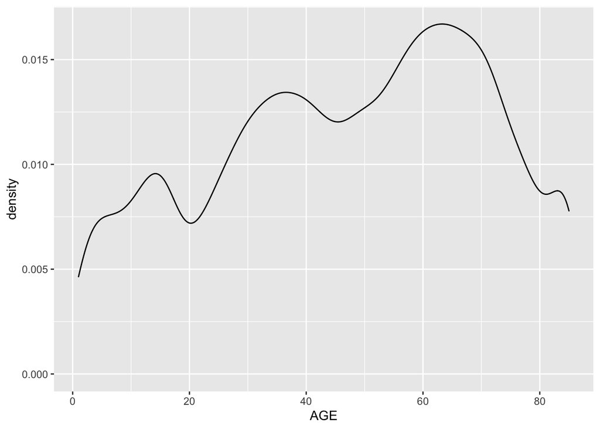

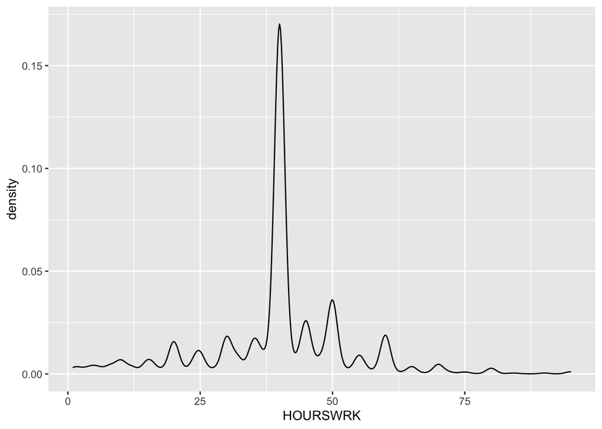

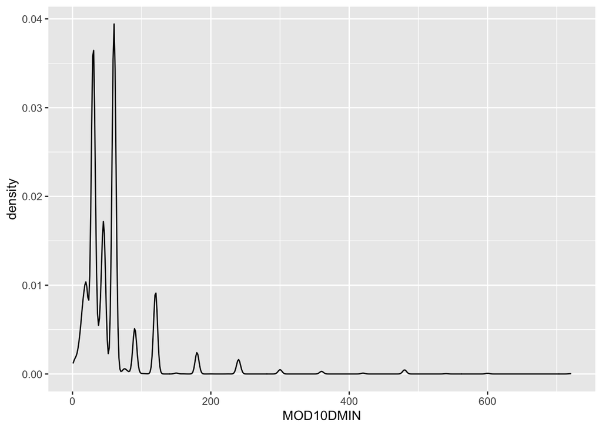

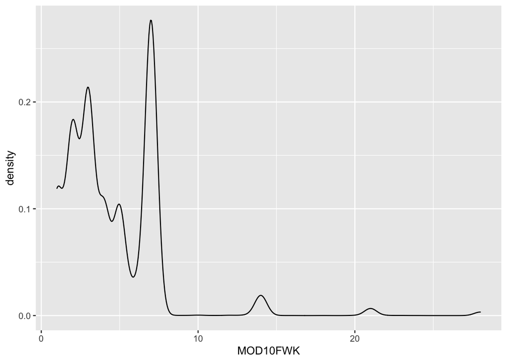

```
##     sexcat            sexoricat     racecat               incomecat
##  female:3328   homosexual  : 146   aian :  51   under $34,999  :1737
##  male  :1571   heterosexual:4303   asian: 114   $35,000-$49,999: 689
##  NA's  :   1   bisexual    : 202   black: 373   $50,000-$74,999: 825
##                other       :  68   other: 145   $75,000-$99,999: 554
##                NA's        : 181   white:4061   over $100,000  :1095
##                                    NA's : 156
##
##      healthcat    insurcat    anxiety       depress          esupport
##  excellent: 578   no  :4573   No :   0   daily  : 733   always   :1017
##  very good:1400   yes : 320   Yes:4900   weekly : 929   usually  : 785
##  good     :1529   NA's:   7              monthly: 803   sometimes: 547
##  fair     : 980                          yearly :1425   rarely   : 235
##  poor     : 411                          never  : 930   never    : 129
##  NA's     :   2                          NA's   :  80   NA's     :2187
##
##   covid                    sympt           AGE           HOURSWRK
##  No  : 885   no symptoms      :  14   Min.   :18.00   Min.   : 1.00
##  Yes :  91   mild symptoms    :  31   1st Qu.:36.00   1st Qu.:32.00
##  NA's:3924   moderate symptoms:  56   Median :51.00   Median :40.00
##              severe symptoms  :  30   Mean   :50.45   Mean   :37.55
##              NA's             :4769   3rd Qu.:64.00   3rd Qu.:42.00
##                                       Max.   :85.00   Max.   :95.00
##                                       NA's   :7       NA's   :2547
##    MOD10DMIN        MOD10FWK         HISPETH           EDUC
##  Min.   :  1.0   Min.   : 1.000   Min.   :10.00   Min.   :102.0
##  1st Qu.: 30.0   1st Qu.: 2.000   1st Qu.:10.00   1st Qu.:201.0
##  Median : 45.0   Median : 3.000   Median :10.00   Median :302.0
##  Mean   : 53.9   Mean   : 4.379   Mean   :12.83   Mean   :312.8
##  3rd Qu.: 60.0   3rd Qu.: 7.000   3rd Qu.:10.00   3rd Qu.:400.0
##  Max.   :720.0   Max.   :28.000   Max.   :93.00   Max.   :999.0
##  NA's   :1832    NA's   :2017
##         reg
##  northeast: 914
##  midwest  :1246
##  south    :1650
##  west     :1090
##
##
##
```

# Kenny’s Analyses

We have 8 variables in our data set with 378 complete cases. We are interested in modeling the relationship between the severity of covid-19 symptoms and the duration of moderate physical activity. In our model, we are adjusting for sex, race, income, health, age.

# Kenny’s EDA

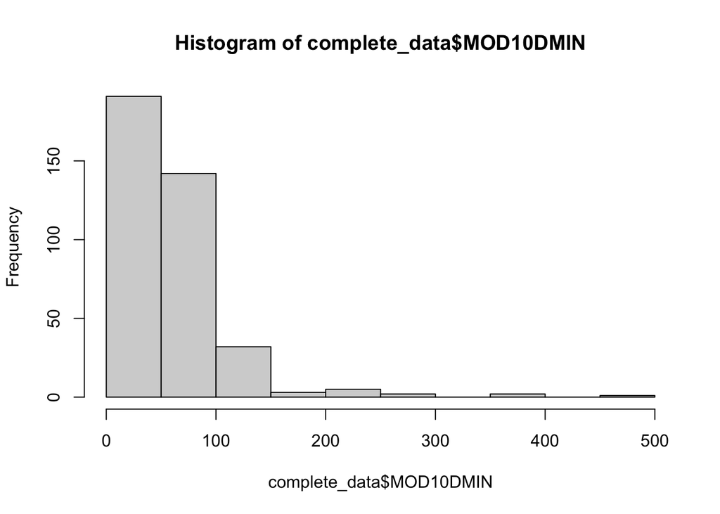

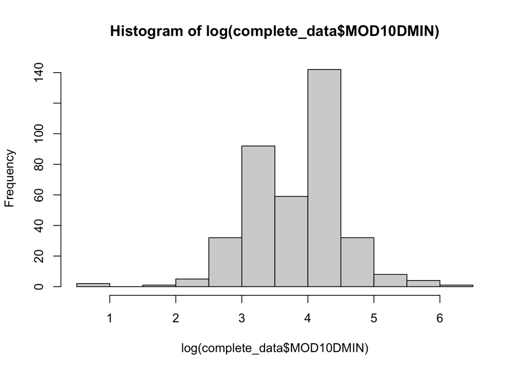

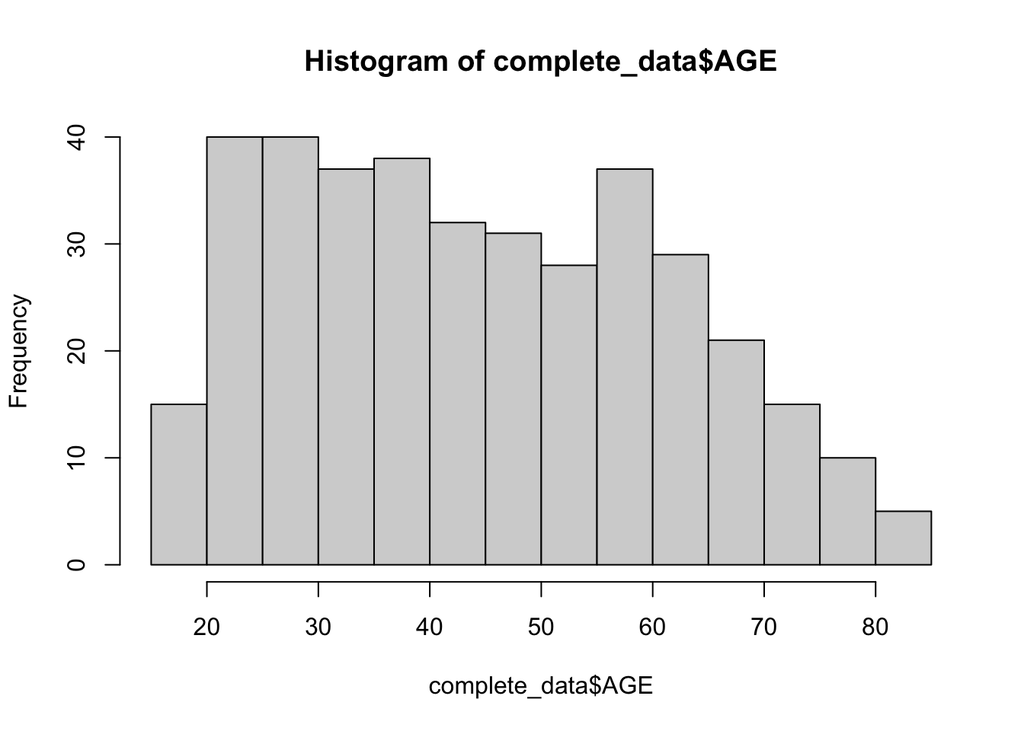

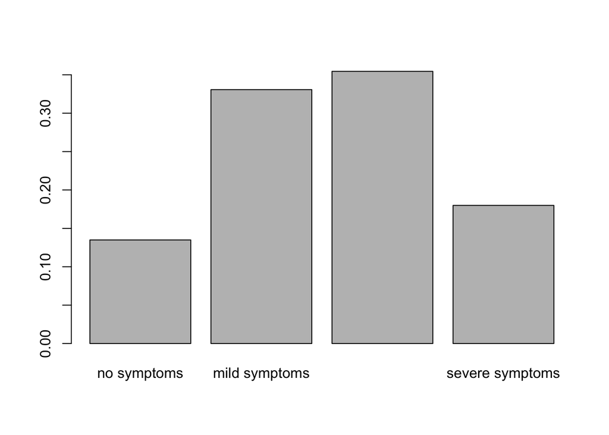

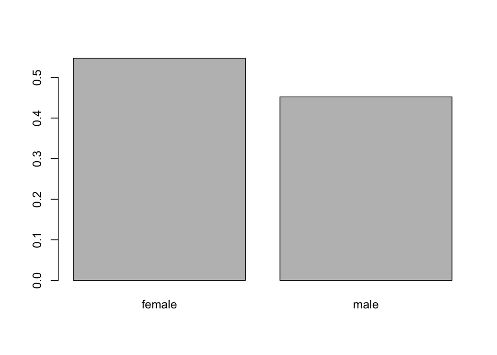

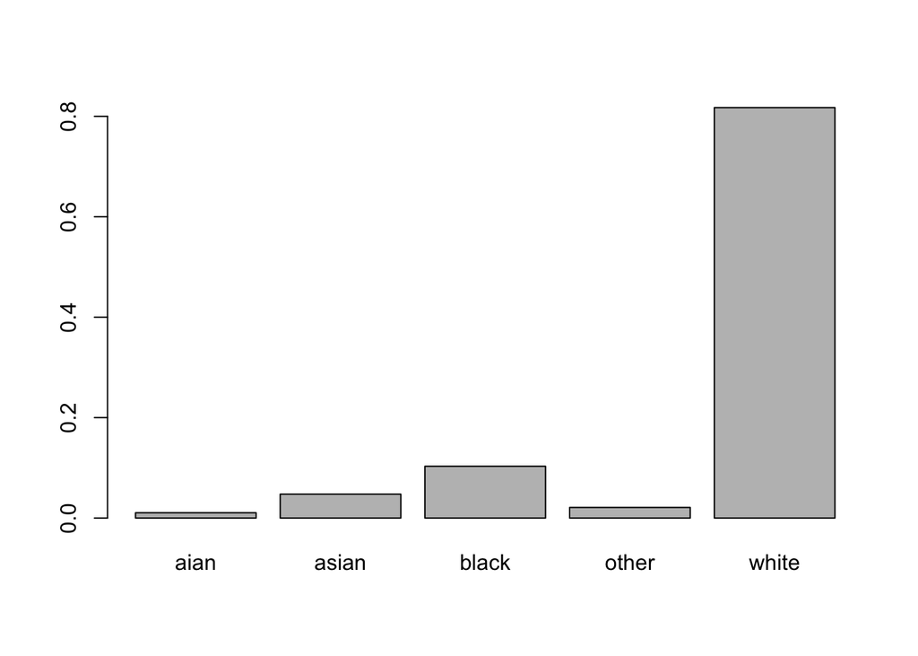

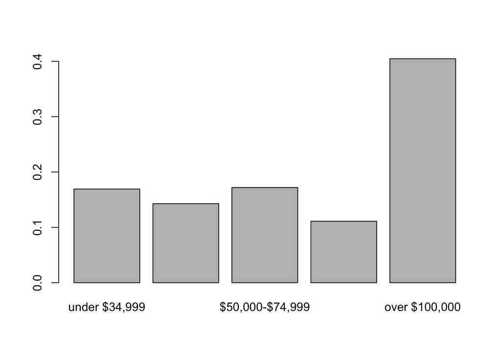

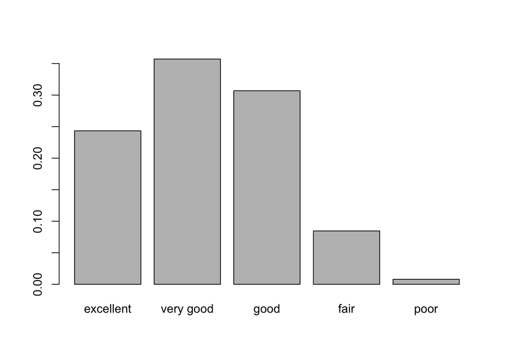

We see that the duration of moderate physical activity is heavily right skewed so we log transformed it.

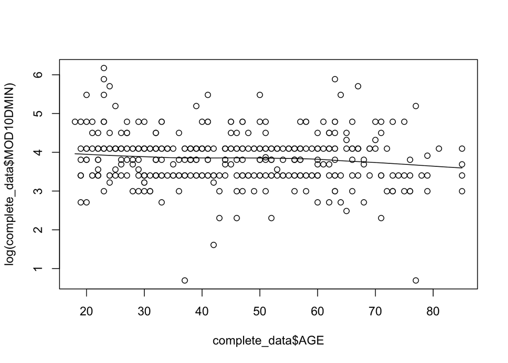

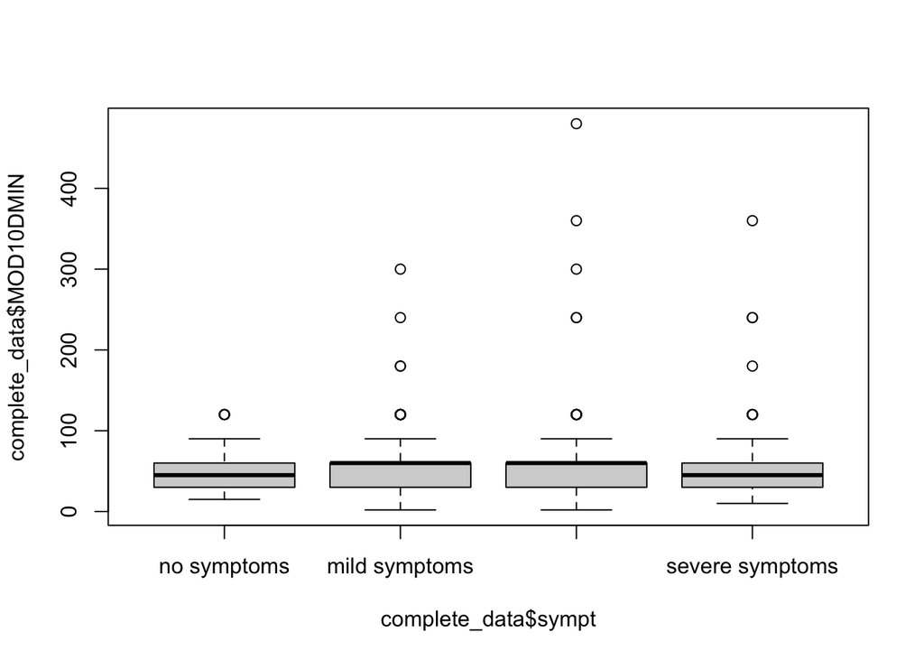

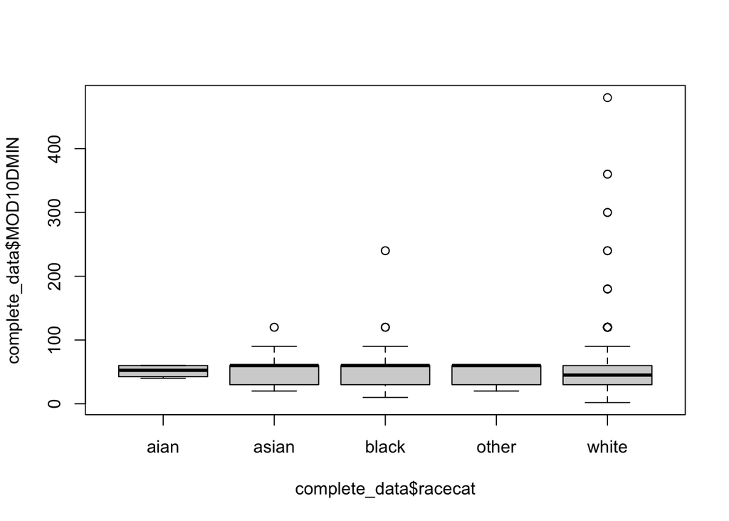

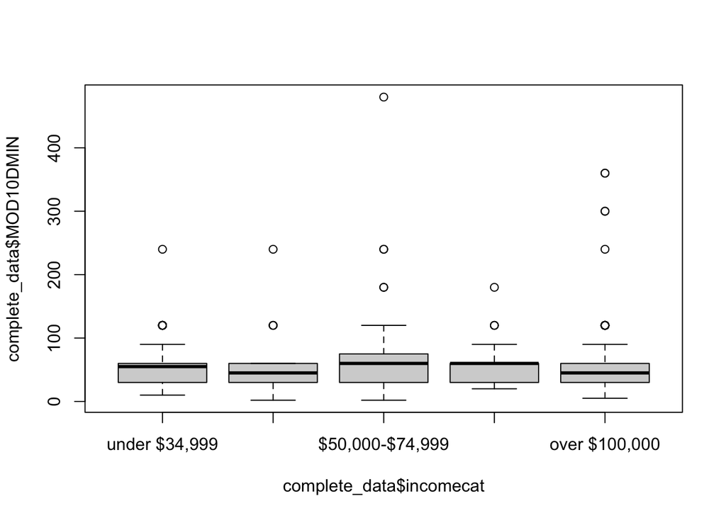

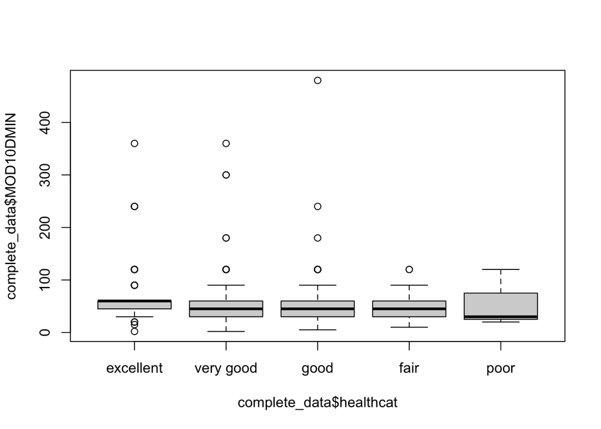

```
##
##  Pearson's Chi-squared test
##
## data:  complete_data$healthcat and complete_data$sympt
## X-squared = 19.923, df = 12, p-value = 0.06856
```

There does not appear to be a linear relationship between age and log(MOD10DMIN) so we might not want to include it in this model. We will keep it for this hw checkin and do some flexible modeling below.

# Fitting the full model

```
## # A tibble: 18 × 5
##    term                     estimate std.error statistic  p.value
##    <chr>                       <dbl>     <dbl>     <dbl>    <dbl>
##  1 (Intercept)               4.25      0.370     11.5    3.20e-26
##  2 sexcatmale               -0.0385    0.0700    -0.551  5.82e- 1
##  3 racecatasian             -0.0726    0.371     -0.196  8.45e- 1
##  4 racecatblack             -0.0675    0.356     -0.190  8.50e- 1
##  5 racecatother             -0.0944    0.412     -0.229  8.19e- 1
##  6 racecatwhite             -0.0744    0.339     -0.219  8.26e- 1
##  7 incomecat$35,000-$49,999 -0.233     0.126     -1.86   6.41e- 2
##  8 incomecat$50,000-$74,999  0.0860    0.118      0.726  4.68e- 1
##  9 incomecat$75,000-$99,999  0.00308   0.135      0.0228 9.82e- 1
## 10 incomecatover $100,000   -0.0201    0.104     -0.194  8.46e- 1
## 11 healthcatvery good       -0.139     0.0911    -1.52   1.28e- 1
## 12 healthcatgood            -0.222     0.0967    -2.29   2.25e- 2
## 13 healthcatfair            -0.329     0.140     -2.34   1.98e- 2
## 14 healthcatpoor            -0.322     0.393     -0.819  4.13e- 1
## 15 symptmild symptoms        0.0624    0.113      0.552  5.81e- 1
## 16 symptmoderate symptoms    0.0458    0.112      0.409  6.83e- 1
## 17 symptsevere symptoms      0.157     0.124      1.27   2.06e- 1
## 18 AGE                      -0.00418   0.00213   -1.96   5.04e- 2
```

In the full model, we see that after adjusting for the effect of the other variables, none of the COVID symptom levels have a statistically significant effect on the duration of moderate physical activity.

# Diagnosis and Model Evaluation

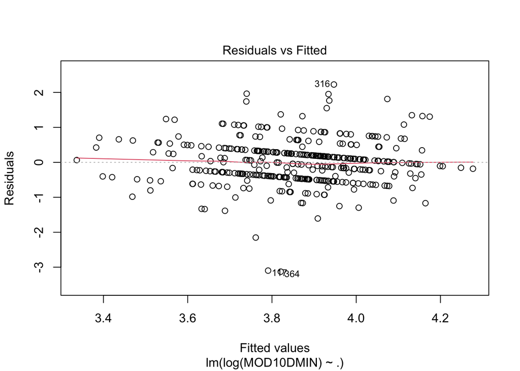

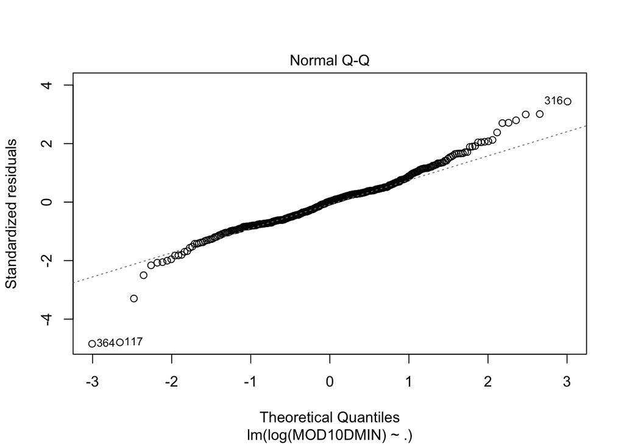

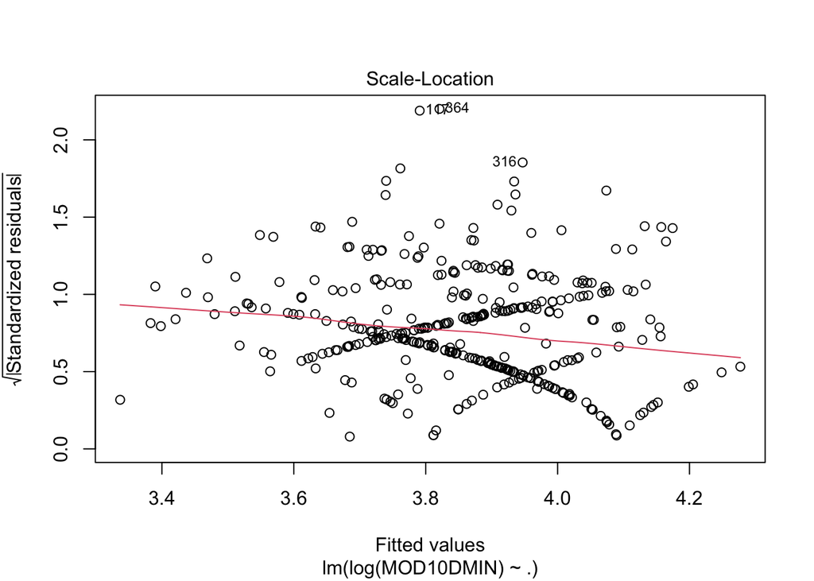

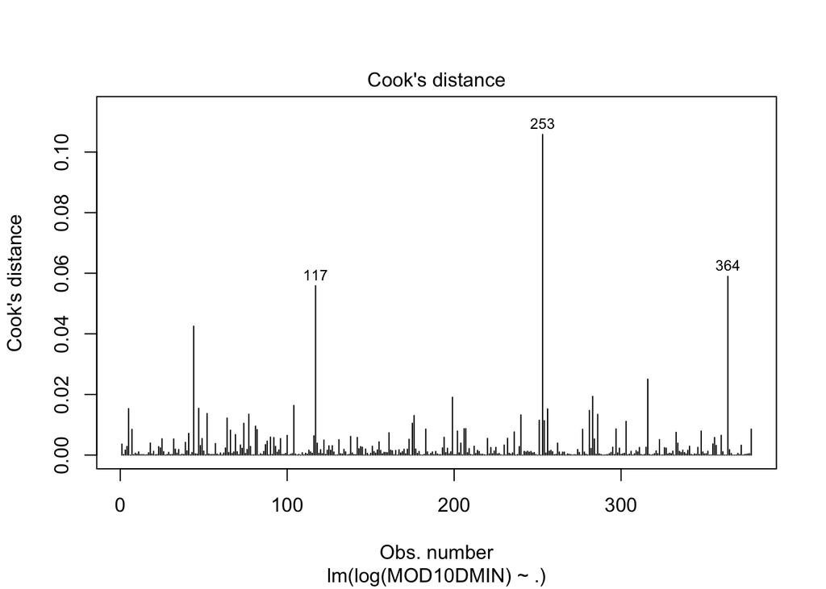

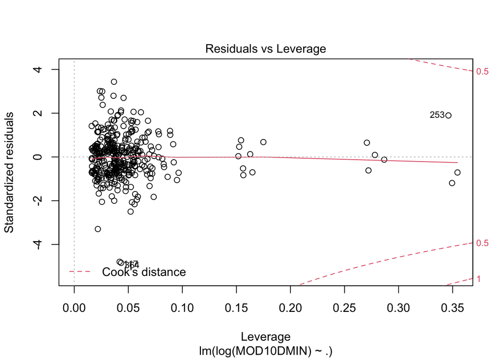

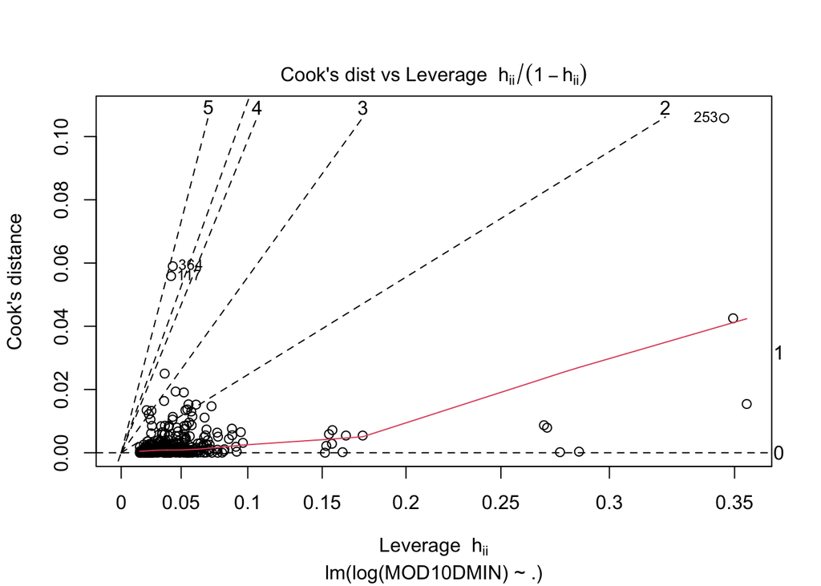

From the residual plots, it seems linearity, normality, and equal variance holds.

# Flexible modeling

```
## Analysis of Variance Table
##
## Model 1: log(MOD10DMIN) ~ sexcat + racecat + incomecat + healthcat + sympt +
##     AGE
## Model 2: log(MOD10DMIN) ~ s(AGE, 4) + (sexcat + racecat + incomecat +
##     healthcat + sympt + AGE)
##   Res.Df    RSS     Df Sum of Sq      F  Pr(>F)
## 1    360 156.97
## 2    357 153.43 2.9997     3.539 2.7451 0.04296 *
## ---
## Signif. codes:  0 '***' 0.001 '**' 0.01 '*' 0.05 '.' 0.1 ' ' 1
```

It seems that it is better to use the GAM model instead of the linear term for Age

# Maria’s Poisson

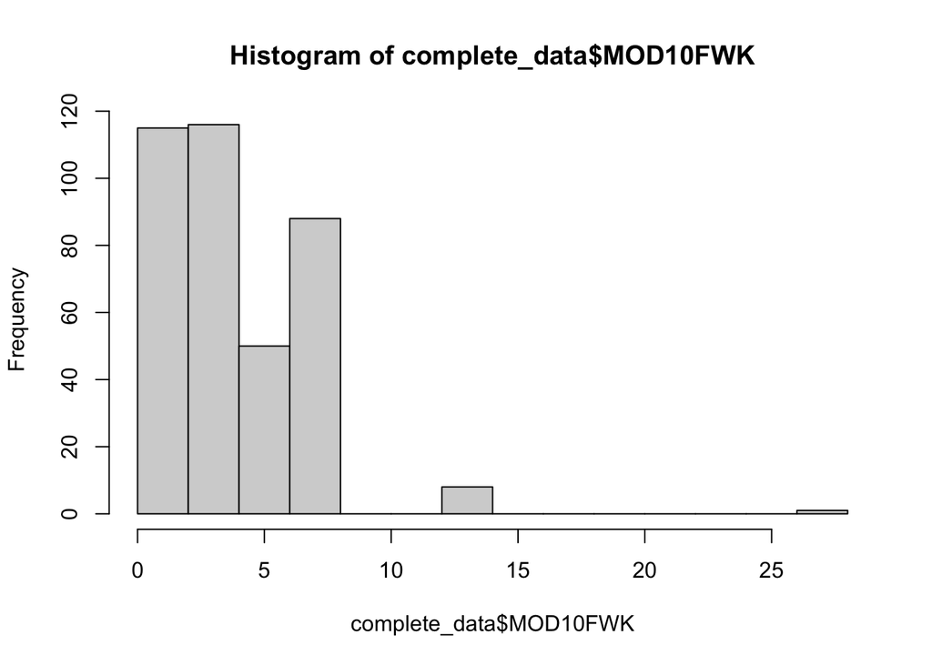

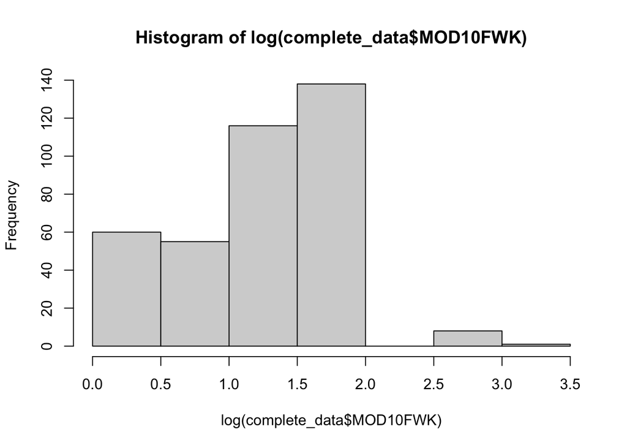

```
## [1] 4.161376
```

```
## [1] 8.103862
```

```
## # A tibble: 18 × 5
##    term                     estimate std.error statistic p.value
##    <chr>                       <dbl>     <dbl>     <dbl>   <dbl>
##  1 (Intercept)               1.02      0.326       3.13  0.00174
##  2 sexcatmale               -0.0267    0.0519     -0.515 0.607
##  3 racecatasian              0.321     0.328       0.977 0.329
##  4 racecatblack              0.366     0.317       1.15  0.249
##  5 racecatother             -0.305     0.387      -0.788 0.431
##  6 racecatwhite              0.350     0.307       1.14  0.254
##  7 incomecat$35,000-$49,999 -0.145     0.0935     -1.55  0.121
##  8 incomecat$50,000-$74,999 -0.123     0.0869     -1.42  0.157
##  9 incomecat$75,000-$99,999  0.0325    0.0963      0.337 0.736
## 10 incomecatover $100,000   -0.125     0.0754     -1.66  0.0971
## 11 healthcatvery good       -0.0809    0.0678     -1.19  0.233
## 12 healthcatgood            -0.00886   0.0706     -0.126 0.900
## 13 healthcatfair            -0.145     0.108      -1.33  0.182
## 14 healthcatpoor             0.0636    0.267       0.238 0.812
## 15 symptmild symptoms        0.0386    0.0864      0.447 0.655
## 16 symptmoderate symptoms    0.101     0.0850      1.19  0.234
## 17 symptsevere symptoms      0.118     0.0930      1.27  0.206
## 18 AGE                       0.00304   0.00157     1.94  0.0524
```

```
## [1] 1.690855
```